# act_report

## Report: act_report

- Create a **250-word-minimum written report** called "act_report.pdf" or "act_report.html" that communicates the insights and displays the visualization(s) produced from your wrangled data. This is to be framed as an external document, like a blog post or magazine article, for example.

## Puppos are rated highest on 'We Rate Dogs!' Twitter!!

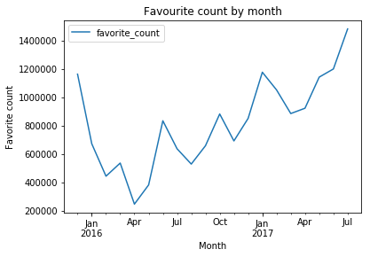

We've also performed some further analysis to understand the individual tweets coming out from the account to help understand whether the account owner has a favorite type of dog! On that note we've uncovered the following insights which suggest that the account owner really likes puppos and Golden Retrievers!

```
1. A puppo is the highest rated dog type from the twitter data that we have analysed. The average rating for a puppo is 12.0, followed by floofer and doggo which both round to 11.8. A pupper has the lowest average rating at 10.8

2. Golden Retrievers have featured more than any other type of dog with 141 images appearing on the account. This is 47 more times than the next most common which was Labrador Retriever (94 images). The third most common was Pembroke, with 88 images.
```

While this is interest, what we really wanted to know is what does the Twitter world think of all of this? It seems that everyone loves the video of a dog learning how to stand in a pool! With 73k retweets, this is the most retweeted tweet that we found and you can enjoy the video for yourself at the following url: https://twitter.com/dog_rates/status/744234799360020481/video/1.